# Risk Factor Analysis

## Outcome Variable

**Outcome Variable:** y_rate_lencm

## Predictor Variables

**Intervention Variable:** nrooms

**Adjustment Set:**

unadjusted

## Stratifying Variables

The analysis was stratified on these variable(s):

- diffcat
- studyid
- country

## Data Summary

| diffcat | studyid | country | nrooms | n_cell | n |
| --- | --- | --- | --- | --- | --- |
| 0-3 months | ki0047075b-MAL-ED | BANGLADESH | 1 | 149 | 237 |
| 0-3 months | ki0047075b-MAL-ED | BANGLADESH | 2 | 49 | 237 |
| 0-3 months | ki0047075b-MAL-ED | BANGLADESH | 3 | 28 | 237 |
| 0-3 months | ki0047075b-MAL-ED | BANGLADESH | 4+ | 11 | 237 |
| 3-6 months | ki0047075b-MAL-ED | BANGLADESH | 1 | 145 | 231 |
| 3-6 months | ki0047075b-MAL-ED | BANGLADESH | 2 | 48 | 231 |
| 3-6 months | ki0047075b-MAL-ED | BANGLADESH | 3 | 27 | 231 |
| 3-6 months | ki0047075b-MAL-ED | BANGLADESH | 4+ | 11 | 231 |
| 6-12 months | ki0047075b-MAL-ED | BANGLADESH | 1 | 139 | 220 |
| 6-12 months | ki0047075b-MAL-ED | BANGLADESH | 2 | 44 | 220 |
| 6-12 months | ki0047075b-MAL-ED | BANGLADESH | 3 | 26 | 220 |
| 6-12 months | ki0047075b-MAL-ED | BANGLADESH | 4+ | 11 | 220 |
| 12-24 months | ki0047075b-MAL-ED | BANGLADESH | 1 | 129 | 206 |
| 12-24 months | ki0047075b-MAL-ED | BANGLADESH | 2 | 39 | 206 |
| 12-24 months | ki0047075b-MAL-ED | BANGLADESH | 3 | 27 | 206 |
| 12-24 months | ki0047075b-MAL-ED | BANGLADESH | 4+ | 11 | 206 |
| 0-3 months | ki1017093b-PROVIDE | BANGLADESH | 1 | 452 | 634 |
| 0-3 months | ki1017093b-PROVIDE | BANGLADESH | 2 | 101 | 634 |
| 0-3 months | ki1017093b-PROVIDE | BANGLADESH | 3 | 59 | 634 |
| 0-3 months | ki1017093b-PROVIDE | BANGLADESH | 4+ | 22 | 634 |
| 3-6 months | ki1017093b-PROVIDE | BANGLADESH | 1 | 406 | 574 |
| 3-6 months | ki1017093b-PROVIDE | BANGLADESH | 2 | 91 | 574 |
| 3-6 months | ki1017093b-PROVIDE | BANGLADESH | 3 | 56 | 574 |
| 3-6 months | ki1017093b-PROVIDE | BANGLADESH | 4+ | 21 | 574 |
| 6-12 months | ki1017093b-PROVIDE | BANGLADESH | 1 | 386 | 545 |
| 6-12 months | ki1017093b-PROVIDE | BANGLADESH | 2 | 86 | 545 |
| 6-12 months | ki1017093b-PROVIDE | BANGLADESH | 3 | 53 | 545 |
| 6-12 months | ki1017093b-PROVIDE | BANGLADESH | 4+ | 20 | 545 |
| 12-24 months | ki1017093b-PROVIDE | BANGLADESH | 1 | 321 | 458 |
| 12-24 months | ki1017093b-PROVIDE | BANGLADESH | 2 | 76 | 458 |

[output cut: 250 more lines]

The following strata were considered:

- diffcat: 0-3 months, studyid: ki0047075b-MAL-ED, country: BANGLADESH
- diffcat: 0-3 months, studyid: ki0047075b-MAL-ED, country: BRAZIL
- diffcat: 0-3 months, studyid: ki0047075b-MAL-ED, country: INDIA
- diffcat: 0-3 months, studyid: ki0047075b-MAL-ED, country: NEPAL
- diffcat: 0-3 months, studyid: ki0047075b-MAL-ED, country: PERU
- diffcat: 0-3 months, studyid: ki0047075b-MAL-ED, country: SOUTH AFRICA
- diffcat: 0-3 months, studyid: ki0047075b-MAL-ED, country: TANZANIA, UNITED REPUBLIC OF
- diffcat: 0-3 months, studyid: ki1000108-CMC-V-BCS-2002, country: INDIA
- diffcat: 0-3 months, studyid: ki1000108-IRC, country: INDIA
- diffcat: 0-3 months, studyid: ki1017093b-PROVIDE, country: BANGLADESH
- diffcat: 0-3 months, studyid: ki1017093c-NIH-Crypto, country: BANGLADESH
- diffcat: 0-3 months, studyid: ki1114097-CONTENT, country: PERU
- diffcat: 0-3 months, studyid: ki1135781-COHORTS, country: INDIA
- diffcat: 0-3 months, studyid: kiGH5241-JiVitA-3, country: BANGLADESH
- diffcat: 0-3 months, studyid: kiGH5241-JiVitA-4, country: BANGLADESH
- diffcat: 12-24 months, studyid: ki0047075b-MAL-ED, country: BANGLADESH
- diffcat: 12-24 months, studyid: ki0047075b-MAL-ED, country: BRAZIL
- diffcat: 12-24 months, studyid: ki0047075b-MAL-ED, country: INDIA
- diffcat: 12-24 months, studyid: ki0047075b-MAL-ED, country: NEPAL
- diffcat: 12-24 months, studyid: ki0047075b-MAL-ED, country: PERU
- diffcat: 12-24 months, studyid: ki0047075b-MAL-ED, country: SOUTH AFRICA
- diffcat: 12-24 months, studyid: ki0047075b-MAL-ED, country: TANZANIA, UNITED REPUBLIC OF
- diffcat: 12-24 months, studyid: ki1000108-CMC-V-BCS-2002, country: INDIA
- diffcat: 12-24 months, studyid: ki1000108-IRC, country: INDIA
- diffcat: 12-24 months, studyid: ki1000304-ZnMort, country: INDIA
- diffcat: 12-24 months, studyid: ki1017093b-PROVIDE, country: BANGLADESH
- diffcat: 12-24 months, studyid: ki1017093c-NIH-Crypto, country: BANGLADESH
- diffcat: 12-24 months, studyid: ki1113344-GMS-Nepal, country: NEPAL
- diffcat: 12-24 months, studyid: ki1114097-CONTENT, country: PERU
- diffcat: 12-24 months, studyid: ki1135781-COHORTS, country: INDIA
- diffcat: 12-24 months, studyid: ki1148112-iLiNS-DOSE, country: MALAWI
- diffcat: 12-24 months, studyid: ki1148112-iLiNS-DYAD-M, country: MALAWI
- diffcat: 12-24 months, studyid: kiGH5241-JiVitA-3, country: BANGLADESH
- diffcat: 12-24 months, studyid: kiGH5241-JiVitA-4, country: BANGLADESH
- diffcat: 3-6 months, studyid: ki0047075b-MAL-ED, country: BANGLADESH
- diffcat: 3-6 months, studyid: ki0047075b-MAL-ED, country: BRAZIL
- diffcat: 3-6 months, studyid: ki0047075b-MAL-ED, country: INDIA
- diffcat: 3-6 months, studyid: ki0047075b-MAL-ED, country: NEPAL
- diffcat: 3-6 months, studyid: ki0047075b-MAL-ED, country: PERU
- diffcat: 3-6 months, studyid: ki0047075b-MAL-ED, country: SOUTH AFRICA
- diffcat: 3-6 months, studyid: ki0047075b-MAL-ED, country: TANZANIA, UNITED REPUBLIC OF
- diffcat: 3-6 months, studyid: ki1000108-CMC-V-BCS-2002, country: INDIA
- diffcat: 3-6 months, studyid: ki1000108-IRC, country: INDIA
- diffcat: 3-6 months, studyid: ki1000304-VITAMIN-A, country: INDIA
- diffcat: 3-6 months, studyid: ki1017093b-PROVIDE, country: BANGLADESH
- diffcat: 3-6 months, studyid: ki1017093c-NIH-Crypto, country: BANGLADESH
- diffcat: 3-6 months, studyid: ki1113344-GMS-Nepal, country: NEPAL
- diffcat: 3-6 months, studyid: ki1114097-CONTENT, country: PERU
- diffcat: 3-6 months, studyid: ki1135781-COHORTS, country: INDIA
- diffcat: 3-6 months, studyid: ki1148112-iLiNS-DYAD-M, country: MALAWI
- diffcat: 3-6 months, studyid: kiGH5241-JiVitA-3, country: BANGLADESH
- diffcat: 3-6 months, studyid: kiGH5241-JiVitA-4, country: BANGLADESH
- diffcat: 6-12 months, studyid: ki0047075b-MAL-ED, country: BANGLADESH
- diffcat: 6-12 months, studyid: ki0047075b-MAL-ED, country: BRAZIL
- diffcat: 6-12 months, studyid: ki0047075b-MAL-ED, country: INDIA
- diffcat: 6-12 months, studyid: ki0047075b-MAL-ED, country: NEPAL
- diffcat: 6-12 months, studyid: ki0047075b-MAL-ED, country: PERU
- diffcat: 6-12 months, studyid: ki0047075b-MAL-ED, country: SOUTH AFRICA
- diffcat: 6-12 months, studyid: ki0047075b-MAL-ED, country: TANZANIA, UNITED REPUBLIC OF
- diffcat: 6-12 months, studyid: ki1000108-CMC-V-BCS-2002, country: INDIA
- diffcat: 6-12 months, studyid: ki1000108-IRC, country: INDIA
- diffcat: 6-12 months, studyid: ki1000125-AgaKhanUniv, country: PAKISTAN
- diffcat: 6-12 months, studyid: ki1000304-VITAMIN-A, country: INDIA
- diffcat: 6-12 months, studyid: ki1017093b-PROVIDE, country: BANGLADESH
- diffcat: 6-12 months, studyid: ki1017093c-NIH-Crypto, country: BANGLADESH
- diffcat: 6-12 months, studyid: ki1113344-GMS-Nepal, country: NEPAL
- diffcat: 6-12 months, studyid: ki1114097-CONTENT, country: PERU
- diffcat: 6-12 months, studyid: ki1135781-COHORTS, country: INDIA
- diffcat: 6-12 months, studyid: ki1148112-iLiNS-DOSE, country: MALAWI
- diffcat: 6-12 months, studyid: ki1148112-iLiNS-DYAD-M, country: MALAWI
- diffcat: 6-12 months, studyid: kiGH5241-JiVitA-3, country: BANGLADESH
- diffcat: 6-12 months, studyid: kiGH5241-JiVitA-4, country: BANGLADESH

### Dropped Strata

Some strata were dropped due to rare outcomes:

- diffcat: 0-3 months, studyid: ki0047075b-MAL-ED, country: BRAZIL
- diffcat: 3-6 months, studyid: ki0047075b-MAL-ED, country: BRAZIL
- diffcat: 6-12 months, studyid: ki0047075b-MAL-ED, country: BRAZIL
- diffcat: 0-3 months, studyid: ki1000108-CMC-V-BCS-2002, country: INDIA
- diffcat: 12-24 months, studyid: ki1000304-ZnMort, country: INDIA
- diffcat: 6-12 months, studyid: ki1148112-iLiNS-DYAD-M, country: MALAWI
- diffcat: 12-24 months, studyid: ki1148112-iLiNS-DYAD-M, country: MALAWI
- diffcat: 3-6 months, studyid: ki1148112-iLiNS-DYAD-M, country: MALAWI
- diffcat: 6-12 months, studyid: ki1000125-AgaKhanUniv, country: PAKISTAN
- diffcat: 0-3 months, studyid: ki1114097-CONTENT, country: PERU

## Methods Detail

We’re interested in the causal parameters $E[Y_a]$ for all values of $a \in \mathcal{A}$. These parameters represent the mean outcome if, possibly contrary to fact, we intervened to set all units to have $A=a$. Under the randomization and positivity assumptions, these are identified by the statistical parameters $\psi_a=E_W[E_{Y|A,W}(Y|A=a,W)]$. In addition, we’re interested in the mean of $Y$, $E[Y]$ under no intervention (the observed mean). We will estimate these parameters by using SuperLearner to fit the relevant likelihood factors – $E_{Y|A,W}(Y|A=a,W)$ and $p(A=a|W)$, and then updating our likelihood fit using a joint TMLE.

For unadjusted analyses ($W=\{\}$), initial likelihoods were estimated using Lrnr_glm to estimate the simple $E(Y|A)$ and Lrnr_mean to estimate $p(A)$. For adjusted analyses, a small library containing Lrnr_glmnet, Lrnr_xgboost, and Lrnr_mean was used.

Having estimated these parameters, we will then use the delta method to estimate relative risks and attributable risks relative to a prespecified baseline level of $A$.

# Results Detail

## Results Plots

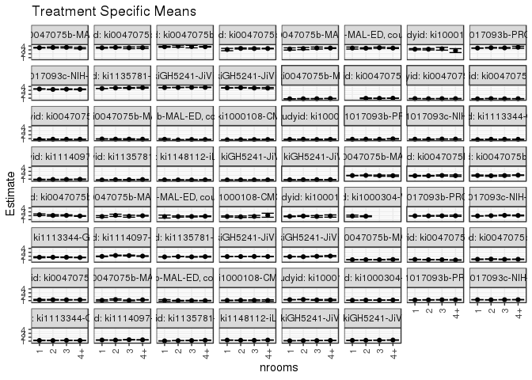

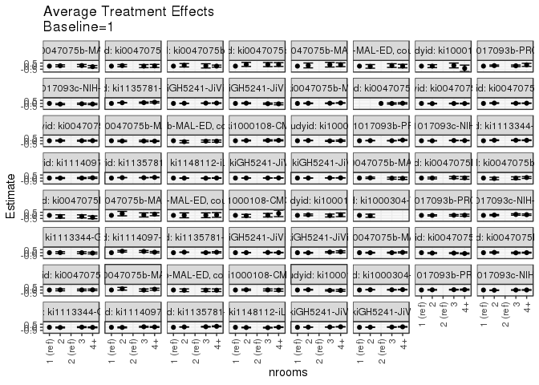

## Results Table

### Parameter: TSM

| diffcat | studyid | country | intervention_level | baseline_level | estimate | ci_lower | ci_upper |
| --- | --- | --- | --- | --- | --- | --- | --- |
| 0-3 months | ki0047075b-MAL-ED | BANGLADESH | 1 | NA | 3.5539807 | 3.4712336 | 3.6367278 |
| 0-3 months | ki0047075b-MAL-ED | BANGLADESH | 2 | NA | 3.6091189 | 3.4718253 | 3.7464125 |
| 0-3 months | ki0047075b-MAL-ED | BANGLADESH | 3 | NA | 3.6410025 | 3.4776860 | 3.8043190 |
| 0-3 months | ki0047075b-MAL-ED | BANGLADESH | 4+ | NA | 3.4660129 | 3.2910080 | 3.6410179 |
| 0-3 months | ki0047075b-MAL-ED | INDIA | 1 | NA | 3.5383665 | 3.4094044 | 3.6673286 |
| 0-3 months | ki0047075b-MAL-ED | INDIA | 2 | NA | 3.6162511 | 3.4958847 | 3.7366175 |
| 0-3 months | ki0047075b-MAL-ED | INDIA | 3 | NA | 3.5368031 | 3.3224719 | 3.7511343 |
| 0-3 months | ki0047075b-MAL-ED | INDIA | 4+ | NA | 3.5682201 | 3.3507489 | 3.7856913 |
| 0-3 months | ki0047075b-MAL-ED | NEPAL | 1 | NA | 3.7962547 | 3.6627994 | 3.9297100 |
| 0-3 months | ki0047075b-MAL-ED | NEPAL | 2 | NA | 3.9384490 | 3.6928833 | 4.1840146 |
| 0-3 months | ki0047075b-MAL-ED | NEPAL | 3 | NA | 3.8360932 | 3.5185353 | 4.1536511 |
| 0-3 months | ki0047075b-MAL-ED | NEPAL | 4+ | NA | 3.7972276 | 3.6988385 | 3.8956167 |
| 0-3 months | ki0047075b-MAL-ED | PERU | 1 | NA | 3.0878556 | 2.7885311 | 3.3871802 |
| 0-3 months | ki0047075b-MAL-ED | PERU | 2 | NA | 3.3693573 | 3.2322199 | 3.5064946 |
| 0-3 months | ki0047075b-MAL-ED | PERU | 3 | NA | 3.3404120 | 3.2012136 | 3.4796103 |
| 0-3 months | ki0047075b-MAL-ED | PERU | 4+ | NA | 3.3503314 | 3.2690696 | 3.4315932 |
| 0-3 months | ki0047075b-MAL-ED | SOUTH AFRICA | 1 | NA | 3.2339657 | 2.9463230 | 3.5216083 |
| 0-3 months | ki0047075b-MAL-ED | SOUTH AFRICA | 2 | NA | 3.3458228 | 3.0686424 | 3.6230032 |
| 0-3 months | ki0047075b-MAL-ED | SOUTH AFRICA | 3 | NA | 3.4664085 | 3.2158892 | 3.7169277 |
| 0-3 months | ki0047075b-MAL-ED | SOUTH AFRICA | 4+ | NA | 3.4603860 | 3.3479478 | 3.5728243 |
| 0-3 months | ki0047075b-MAL-ED | TANZANIA, UNITED REPUBLIC OF | 1 | NA | 3.4605668 | 3.2031257 | 3.7180079 |
| 0-3 months | ki0047075b-MAL-ED | TANZANIA, UNITED REPUBLIC OF | 2 | NA | 3.4201221 | 3.2739030 | 3.5663411 |
| 0-3 months | ki0047075b-MAL-ED | TANZANIA, UNITED REPUBLIC OF | 3 | NA | 3.5516299 | 3.3898203 | 3.7134394 |
| 0-3 months | ki0047075b-MAL-ED | TANZANIA, UNITED REPUBLIC OF | 4+ | NA | 3.4633743 | 3.3452857 | 3.5814630 |
| 0-3 months | ki1000108-IRC | INDIA | 1 | NA | 3.1771047 | 3.0179112 | 3.3362982 |
| 0-3 months | ki1000108-IRC | INDIA | 2 | NA | 3.1724991 | 2.9881312 | 3.3568671 |
| 0-3 months | ki1000108-IRC | INDIA | 3 | NA | 3.2850514 | 2.9227093 | 3.6473934 |
| 0-3 months | ki1000108-IRC | INDIA | 4+ | NA | 2.8216162 | 2.3216109 | 3.3216214 |
| 0-3 months | ki1017093b-PROVIDE | BANGLADESH | 1 | NA | 3.4578242 | 3.4113055 | 3.5043429 |
| 0-3 months | ki1017093b-PROVIDE | BANGLADESH | 2 | NA | 3.5377847 | 3.4449992 | 3.6305702 |

[output cut: 215 more lines]

### Parameter: E(Y)

| diffcat | studyid | country | intervention_level | baseline_level | estimate | ci_lower | ci_upper |
| --- | --- | --- | --- | --- | --- | --- | --- |
| 0-3 months | ki0047075b-MAL-ED | BANGLADESH | NA | NA | 3.5715787 | 3.5085237 | 3.6346338 |
| 0-3 months | ki0047075b-MAL-ED | INDIA | NA | NA | 3.5688019 | 3.4917177 | 3.6458861 |
| 0-3 months | ki0047075b-MAL-ED | NEPAL | NA | NA | 3.8178619 | 3.7415249 | 3.8941989 |
| 0-3 months | ki0047075b-MAL-ED | PERU | NA | NA | 3.3345392 | 3.2720665 | 3.3970119 |
| 0-3 months | ki0047075b-MAL-ED | SOUTH AFRICA | NA | NA | 3.4366827 | 3.3435842 | 3.5297813 |
| 0-3 months | ki0047075b-MAL-ED | TANZANIA, UNITED REPUBLIC OF | NA | NA | 3.4772891 | 3.3996638 | 3.5549143 |
| 0-3 months | ki1000108-IRC | INDIA | NA | NA | 3.1685972 | 3.0563410 | 3.2808533 |
| 0-3 months | ki1017093b-PROVIDE | BANGLADESH | NA | NA | 3.4826706 | 3.4434873 | 3.5218539 |
| 0-3 months | ki1017093c-NIH-Crypto | BANGLADESH | NA | NA | 3.3028656 | 3.2646714 | 3.3410598 |
| 0-3 months | ki1135781-COHORTS | INDIA | NA | NA | 3.5329262 | 3.5160350 | 3.5498174 |
| 0-3 months | kiGH5241-JiVitA-3 | BANGLADESH | NA | NA | 3.7183577 | 3.7080161 | 3.7286992 |
| 0-3 months | kiGH5241-JiVitA-4 | BANGLADESH | NA | NA | 3.6386177 | 3.6075243 | 3.6697112 |
| 3-6 months | ki0047075b-MAL-ED | BANGLADESH | NA | NA | 1.9280462 | 1.8787523 | 1.9773401 |
| 3-6 months | ki0047075b-MAL-ED | INDIA | NA | NA | 1.8837264 | 1.8224393 | 1.9450135 |
| 3-6 months | ki0047075b-MAL-ED | NEPAL | NA | NA | 1.9680995 | 1.9120346 | 2.0241643 |
| 3-6 months | ki0047075b-MAL-ED | PERU | NA | NA | 2.0183213 | 1.9525900 | 2.0840526 |
| 3-6 months | ki0047075b-MAL-ED | SOUTH AFRICA | NA | NA | 1.9877371 | 1.9066803 | 2.0687939 |
| 3-6 months | ki0047075b-MAL-ED | TANZANIA, UNITED REPUBLIC OF | NA | NA | 1.8300902 | 1.7622436 | 1.8979368 |
| 3-6 months | ki1000108-CMC-V-BCS-2002 | INDIA | NA | NA | 1.8037880 | 1.7029866 | 1.9045894 |
| 3-6 months | ki1000108-IRC | INDIA | NA | NA | 1.8759294 | 1.8124309 | 1.9394280 |
| 3-6 months | ki1000304-VITAMIN-A | INDIA | NA | NA | 1.8992731 | 1.6422794 | 2.1562667 |
| 3-6 months | ki1017093b-PROVIDE | BANGLADESH | NA | NA | 1.9654454 | 1.9303798 | 2.0005110 |
| 3-6 months | ki1017093c-NIH-Crypto | BANGLADESH | NA | NA | 2.0057973 | 1.9693775 | 2.0422170 |
| 3-6 months | ki1113344-GMS-Nepal | NEPAL | NA | NA | 1.7057418 | 1.6666784 | 1.7448052 |
| 3-6 months | ki1114097-CONTENT | PERU | NA | NA | 2.0841841 | 2.0362519 | 2.1321163 |
| 3-6 months | ki1135781-COHORTS | INDIA | NA | NA | 1.8574178 | 1.8434023 | 1.8714334 |
| 3-6 months | kiGH5241-JiVitA-3 | BANGLADESH | NA | NA | 1.9202659 | 1.9098042 | 1.9307275 |
| 3-6 months | kiGH5241-JiVitA-4 | BANGLADESH | NA | NA | 1.8987567 | 1.8688242 | 1.9286892 |
| 6-12 months | ki0047075b-MAL-ED | BANGLADESH | NA | NA | 1.1143928 | 1.0896103 | 1.1391753 |
| 6-12 months | ki0047075b-MAL-ED | INDIA | NA | NA | 1.1210558 | 1.0926349 | 1.1494766 |
| 6-12 months | ki0047075b-MAL-ED | NEPAL | NA | NA | 1.2224454 | 1.1966480 | 1.2482429 |
| 6-12 months | ki0047075b-MAL-ED | PERU | NA | NA | 1.2102315 | 1.1775158 | 1.2429472 |
| 6-12 months | ki0047075b-MAL-ED | SOUTH AFRICA | NA | NA | 1.1895267 | 1.1483723 | 1.2306812 |
| 6-12 months | ki0047075b-MAL-ED | TANZANIA, UNITED REPUBLIC OF | NA | NA | 1.0019524 | 0.9648566 | 1.0390481 |
| 6-12 months | ki1000108-CMC-V-BCS-2002 | INDIA | NA | NA | 1.0624474 | 1.0146679 | 1.1102268 |
| 6-12 months | ki1000108-IRC | INDIA | NA | NA | 1.2493708 | 1.2200516 | 1.2786900 |
| 6-12 months | ki1000304-VITAMIN-A | INDIA | NA | NA | 1.1102685 | 1.0984326 | 1.1221045 |
| 6-12 months | ki1017093b-PROVIDE | BANGLADESH | NA | NA | 1.1731762 | 1.1558671 | 1.1904853 |
| 6-12 months | ki1017093c-NIH-Crypto | BANGLADESH | NA | NA | 1.2281313 | 1.2106849 | 1.2455776 |
| 6-12 months | ki1113344-GMS-Nepal | NEPAL | NA | NA | 1.1681560 | 1.1485303 | 1.1877817 |
| 6-12 months | ki1114097-CONTENT | PERU | NA | NA | 1.3010517 | 1.2719491 | 1.3301542 |
| 6-12 months | ki1135781-COHORTS | INDIA | NA | NA | 1.0833099 | 1.0736358 | 1.0929841 |
| 6-12 months | ki1148112-iLiNS-DOSE | MALAWI | NA | NA | 1.2232963 | 1.2062241 | 1.2403684 |
| 6-12 months | kiGH5241-JiVitA-3 | BANGLADESH | NA | NA | 1.1069339 | 1.1001844 | 1.1136835 |
| 6-12 months | kiGH5241-JiVitA-4 | BANGLADESH | NA | NA | 1.2031603 | 1.1927643 | 1.2135564 |
| 12-24 months | ki0047075b-MAL-ED | BANGLADESH | NA | NA | 0.8459764 | 0.8299714 | 0.8619814 |
| 12-24 months | ki0047075b-MAL-ED | BRAZIL | NA | NA | 0.9816245 | 0.9508764 | 1.0123725 |
| 12-24 months | ki0047075b-MAL-ED | INDIA | NA | NA | 0.8803730 | 0.8630530 | 0.8976931 |
| 12-24 months | ki0047075b-MAL-ED | NEPAL | NA | NA | 0.8617083 | 0.8463512 | 0.8770654 |
| 12-24 months | ki0047075b-MAL-ED | PERU | NA | NA | 0.8463453 | 0.8256453 | 0.8670453 |
| 12-24 months | ki0047075b-MAL-ED | SOUTH AFRICA | NA | NA | 0.8699064 | 0.8475321 | 0.8922808 |
| 12-24 months | ki0047075b-MAL-ED | TANZANIA, UNITED REPUBLIC OF | NA | NA | 0.7663111 | 0.7428636 | 0.7897586 |
| 12-24 months | ki1000108-CMC-V-BCS-2002 | INDIA | NA | NA | 0.7397013 | 0.7128622 | 0.7665404 |
| 12-24 months | ki1000108-IRC | INDIA | NA | NA | 0.8304303 | 0.8110434 | 0.8498173 |
| 12-24 months | ki1017093b-PROVIDE | BANGLADESH | NA | NA | 0.8575519 | 0.8455586 | 0.8695452 |
| 12-24 months | ki1017093c-NIH-Crypto | BANGLADESH | NA | NA | 0.8755729 | 0.8637860 | 0.8873598 |
| 12-24 months | ki1113344-GMS-Nepal | NEPAL | NA | NA | 0.8378848 | 0.8224521 | 0.8533174 |
| 12-24 months | ki1114097-CONTENT | PERU | NA | NA | 0.9259464 | 0.8927736 | 0.9591191 |
| 12-24 months | ki1135781-COHORTS | INDIA | NA | NA | 0.8192215 | 0.8133282 | 0.8251148 |
| 12-24 months | ki1148112-iLiNS-DOSE | MALAWI | NA | NA | 0.8081310 | 0.7940843 | 0.8221776 |
| 12-24 months | kiGH5241-JiVitA-3 | BANGLADESH | NA | NA | 0.7966441 | 0.7913288 | 0.8019594 |
| 12-24 months | kiGH5241-JiVitA-4 | BANGLADESH | NA | NA | 0.8492263 | 0.8437928 | 0.8546597 |

### Parameter: ATE

| diffcat | studyid | country | intervention_level | baseline_level | estimate | ci_lower | ci_upper |
| --- | --- | --- | --- | --- | --- | --- | --- |
| 0-3 months | ki0047075b-MAL-ED | BANGLADESH | 1 | 1 | 0.0000000 | 0.0000000 | 0.0000000 |
| 0-3 months | ki0047075b-MAL-ED | BANGLADESH | 2 | 1 | 0.0551382 | -0.1051634 | 0.2154399 |
| 0-3 months | ki0047075b-MAL-ED | BANGLADESH | 3 | 1 | 0.0870218 | -0.0960611 | 0.2701048 |
| 0-3 months | ki0047075b-MAL-ED | BANGLADESH | 4+ | 1 | -0.0879677 | -0.2815493 | 0.1056138 |
| 0-3 months | ki0047075b-MAL-ED | INDIA | 1 | 1 | 0.0000000 | 0.0000000 | 0.0000000 |
| 0-3 months | ki0047075b-MAL-ED | INDIA | 2 | 1 | 0.0778846 | -0.0985220 | 0.2542912 |
| 0-3 months | ki0047075b-MAL-ED | INDIA | 3 | 1 | -0.0015634 | -0.2517016 | 0.2485748 |
| 0-3 months | ki0047075b-MAL-ED | INDIA | 4+ | 1 | 0.0298536 | -0.2229802 | 0.2826874 |
| 0-3 months | ki0047075b-MAL-ED | NEPAL | 1 | 1 | 0.0000000 | 0.0000000 | 0.0000000 |
| 0-3 months | ki0047075b-MAL-ED | NEPAL | 2 | 1 | 0.1421943 | -0.1372924 | 0.4216809 |
| 0-3 months | ki0047075b-MAL-ED | NEPAL | 3 | 1 | 0.0398386 | -0.3046224 | 0.3842995 |
| 0-3 months | ki0047075b-MAL-ED | NEPAL | 4+ | 1 | 0.0009730 | -0.1648303 | 0.1667762 |
| 0-3 months | ki0047075b-MAL-ED | PERU | 1 | 1 | 0.0000000 | 0.0000000 | 0.0000000 |
| 0-3 months | ki0047075b-MAL-ED | PERU | 2 | 1 | 0.2815016 | -0.0477427 | 0.6107459 |
| 0-3 months | ki0047075b-MAL-ED | PERU | 3 | 1 | 0.2525563 | -0.0775518 | 0.5826644 |
| 0-3 months | ki0047075b-MAL-ED | PERU | 4+ | 1 | 0.2624758 | -0.0476833 | 0.5726348 |
| 0-3 months | ki0047075b-MAL-ED | SOUTH AFRICA | 1 | 1 | 0.0000000 | 0.0000000 | 0.0000000 |
| 0-3 months | ki0047075b-MAL-ED | SOUTH AFRICA | 2 | 1 | 0.1118572 | -0.2876015 | 0.5113158 |
| 0-3 months | ki0047075b-MAL-ED | SOUTH AFRICA | 3 | 1 | 0.2324428 | -0.1489994 | 0.6138851 |
| 0-3 months | ki0047075b-MAL-ED | SOUTH AFRICA | 4+ | 1 | 0.2264204 | -0.0824171 | 0.5352579 |
| 0-3 months | ki0047075b-MAL-ED | TANZANIA, UNITED REPUBLIC OF | 1 | 1 | 0.0000000 | 0.0000000 | 0.0000000 |
| 0-3 months | ki0047075b-MAL-ED | TANZANIA, UNITED REPUBLIC OF | 2 | 1 | -0.0404447 | -0.3365122 | 0.2556228 |
| 0-3 months | ki0047075b-MAL-ED | TANZANIA, UNITED REPUBLIC OF | 3 | 1 | 0.0910631 | -0.2130065 | 0.3951326 |
| 0-3 months | ki0047075b-MAL-ED | TANZANIA, UNITED REPUBLIC OF | 4+ | 1 | 0.0028075 | -0.2804254 | 0.2860404 |
| 0-3 months | ki1000108-IRC | INDIA | 1 | 1 | 0.0000000 | 0.0000000 | 0.0000000 |
| 0-3 months | ki1000108-IRC | INDIA | 2 | 1 | -0.0046056 | -0.2481915 | 0.2389804 |
| 0-3 months | ki1000108-IRC | INDIA | 3 | 1 | 0.1079467 | -0.2878239 | 0.5037172 |
| 0-3 months | ki1000108-IRC | INDIA | 4+ | 1 | -0.3554886 | -0.8802245 | 0.1692474 |
| 0-3 months | ki1017093b-PROVIDE | BANGLADESH | 1 | 1 | 0.0000000 | 0.0000000 | 0.0000000 |
| 0-3 months | ki1017093b-PROVIDE | BANGLADESH | 2 | 1 | 0.0799605 | -0.0238332 | 0.1837542 |

[output cut: 215 more lines]